# Bilsammenligning — vægtet pointmodel

Skalerer til vilkårligt mange biler

06 September 2026

## Sådan virker modellen

Det gamle værktøj gav point parvist (én bil +, én bil −) og kunne kun håndtere to biler. Denne model er **absolut og vægtet**, så den skalerer til vilkårligt mange biler — brede tabeller kan scrolles vandret.

1. **Data** ligger i store_biler_specs.csv — én række pr. parameter, én kolonne pr. bil. Tilføj en bil = tilføj en kolonne; tilføj en parameter = tilføj en række.
2. Hver parameter har en **`kategori`** (én af de 8 prioriteter, eller `info` = vises men tæller ikke med) og en **`retning`** (`hoej` = højere er bedst, `lav` = lavere er bedst). En parameter kan tilhøre flere kategorier adskilt med `;`.
3. **Normalisering pr. parameter (ratio-skala).** Den bedste bil får 1,0 og de øvrige proportionalt: for `hoej` er score $x/\max(x)$, for `lav` er $\min(x)/x$. Marginens størrelse bevares.
4. **Robust over for huller.** Mangler en bil en værdi, springes den over for netop den parameter; en parameter scorer, så længe mindst to biler har data. Hver bils slutindeks normaliseres med vægten af de kategorier, bilen *har* data for — så manglende felter hverken straffer eller belønner kunstigt.
5. **Kategoriscore** = gennemsnit af parameter-scorerne i kategorien. **Slutindeks** = vægtet gennemsnit (vægte i store_biler_vaegte.csv), skaleret 0–100.

## Specifikationer (rådata)

Vandret scroll viser alle biler. `—` = ukendt/ikke udfyldt.

| Parameter | Enhed | Suzuki_e_Vitara | Citroen_eC5_Aircross | MG_MGS5 | Peugeot_e3008 | Hyundai_Ioniq5 | Nissan_Ariya | Renault_Scenic | MINI_Countryman_E | VW_ID4_Pro | Subaru_Uncharted | Subaru_E_Outback | Volvo_EX40 | Skoda_Enyaq_85x | Kategori |
| --- | --- | --- | --- | --- | --- | --- | --- | --- | --- | --- | --- | --- | --- | --- | --- |
| Basispris | kr | 246.990 | 259.990 | 269.999 | 279.990 | 279.995 | 299.900 | 299.990 | 300.475 | 347.990 | 349.900 | 369.900 | 374.900 | 374.995 | oekonomi |
| Maerke | navn | Suzuki | Citroën | MG | Peugeot | Hyundai | Nissan | Renault | MINI | VW | Subaru | Subaru | Volvo | Skoda | info |
| Varmepumpe | ja=1 | 1 | 1 | 1 | 1 | 1 | 1 | 1 | 1 | 1 | 1 | 1 | 1 | 1 | info |
| Forkonditionering | ja=1 | 1 | 1 | 1 | 1 | 1 | 1 | 1 | 1 | 1 | 1 | 1 | 1 | 1 | info |
| Doere | antal | 5 | 5 | 5 | 5 | 5 | 5 | 5 | 5 | 5 | 5 | 5 | 5 | 5 | info |
| Raekkevidde | km | 426 | 520 | 477 | 525 | 570 | 536 | 625 | 462 | 570 | 495 | 526 | 576 | 525 | komfort |
| Batteri_kWh | kWh | 59,8 | 73,7 | 62,1 | 73 | 80 | 87 | 87 | 65,2 | 79 | 77 | 74,7 | 79 | 77 | info |
| DC_ladeeffekt | kW | 70 | 160 | 139 | 160 | 233 | 130 | 150 | 130 | 165 | 150 | 150 | 207 | 175 | komfort |
| Motor_effekt | hk | 174 | 211 | 228 | 213 | 228 | 242 | 220 | 201 | 286 | 343 | 380 | 252 | 286 | foere_sne |
| Drivlinje_AWD | awd | 0 | 0 | 0 | 0 | 0 | 0 | 0 | 0 | 0 | 1 | 1 | 0 | 1 | foere_sne |
| Vaegt | kg | 1.835 | 2.184 | 1.755 | 2.183 | 2.060 | 2.121 | 1.917 | 1.940 | 2.136 | 2.189 | 2.105 | 2.075 | 2.220 | info |
| Frihoejde | mm | — | — | — | — | — | — | — | — | — | 211 | 211 | — | 163 | foere_sne;fartbump |
| Bagagerum | liter | 238 | 565 | 453 | 588 | 520 | 468 | 545 | 460 | 533 | 403 | 669 | 410 | 585 | rummelig |
| Bagagerum_max | liter | 562 | 1.668 | 1.441 | 1.663 | 1.580 | 1.350 | 1.670 | 1.450 | 1.565 | — | 1.718 | 1.286 | 1.710 | info |
| Akselafstand | mm | 2.700 | 2.795 | 2.730 | 2.739 | 3.000 | 2.775 | 2.785 | 2.692 | 2.771 | 2.750 | 2.850 | 2.702 | 2.765 | komfort |
| Daekside | mm | — | — | — | — | — | — | — | — | — | — | 141 | — | 129 | fartbump |
| Anhaengertraek | kg | 750 | 1.250 | 750 | 1.250 | 1.600 | 750 | 1.100 | 750 | 1.000 | 1.500 | 1.500 | 1.500 | 2.000 | info |
| Garanti_bil_aar | aar | 6 | 8 | 7 | 8 | 5 | 3 | 5 | 2 | 5 | 10 | 10 | 5 | 5 | driftsikkerhed |
| Garanti_batteri_aar | aar | 8 | 8 | 7 | 8 | 8 | 8 | 8 | 8 | 8 | 10 | 10 | 8 | 8 | driftsikkerhed |
| Garanti_km | km | 150.000 | 160.000 | 150.000 | 160.000 | ubegrænset | 100.000 | 150.000 | ubegrænset | 150.000 | 200.000 | 200.000 | 200.000 | 150.000 | info |
| NCAP_stjerner | stjerner | — | — | — | 5 | 5 | 5 | 5 | 5 | 5 | — | 5 | 5 | 5 | personsikkerhed |
| NCAP_adult | pct | — | — | — | — | — | — | — | — | — | — | 89 | — | 94 | info |
| NCAP_child | pct | — | — | — | — | — | — | — | — | — | — | 85 | — | 89 | info |
| NCAP_vru | pct | — | — | — | — | — | — | — | — | — | — | 80 | — | 71 | info |
| NCAP_safety_assist | pct | — | — | — | — | — | — | — | — | — | — | 79 | — | 82 | info |
| Forhandler_afstand | km | — | — | — | — | — | — | — | — | — | — | — | — | — | forhandler |
| Vaerditab_pct_aar | pct | — | 7,1 | — | 11,3 | 10 | 13,5 | 13,7 | 17,4 | 18,3 | — | — | 11,1 | 11,5 | info |
| Vaerditab_4aar | kr | — | 66.339 | — | 106.675 | 96.290 | 132.004 | 133.591 | 160.604 | 192.946 | — | — | 140.735 | 144.958 | oekonomi |
| Drift_4aar | kr | 23.162 | 23.386 | 21.481 | 22.943 | 23.158 | 26.782 | 22.968 | 23.286 | 22.868 | 25.667 | 23.433 | 22.630 | 24.200 | oekonomi |

## Prioriteter og vægte

| Prioritet | Kategori | Vægt | Har data |
| --- | --- | --- | --- |
| 1 | Driftsikkerhed | 8 | ja |
| 2 | Personsikkerhed | 7 | ja |
| 3 | Dårligt føre/sne | 6 | ja |
| 4 | Samlet økonomi | 5 | ja |
| 5 | Rummelig | 4 | ja |
| 6 | Komfort (for- og bagsæder) | 3 | ja |
| 7 | Forhandler+service i nærområdet | 2 | — |
| 8 | Fartbump+rundkørsel | 1 | ja |

Udeladt (under to biler har værdi): **Forhandler_afstand**.

## Kategoriscorer (0–100)

Hvor godt hver bil klarer hver prioritet, før vægtning.

| Kategori | Vægt | Suzuki_e_Vitara | Citroen_eC5_Aircross | MG_MGS5 | Peugeot_e3008 | Hyundai_Ioniq5 | Nissan_Ariya | Renault_Scenic | MINI_Countryman_E | VW_ID4_Pro | Subaru_Uncharted | Subaru_E_Outback | Volvo_EX40 | Skoda_Enyaq_85x |
| --- | --- | --- | --- | --- | --- | --- | --- | --- | --- | --- | --- | --- | --- | --- |
| Driftsikkerhed | 8 | 70 | 80 | 70 | 80 | 65 | 55 | 65 | 50 | 65 | 100 | 100 | 65 | 65 |
| Personsikkerhed | 7 | — | — | — | 100 | 100 | 100 | 100 | 100 | 100 | — | 100 | 100 | 100 |
| Dårligt føre/sne | 6 | 23 | 28 | 30 | 28 | 30 | 32 | 29 | 26 | 38 | 97 | 100 | 33 | 84 |
| Samlet økonomi | 5 | 96 | 96 | 96 | 81 | 83 | 71 | 75 | 72 | 66 | 77 | 79 | 69 | 67 |
| Rummelig | 4 | 36 | 84 | 68 | 88 | 78 | 70 | 81 | 69 | 80 | 60 | 100 | 61 | 87 |
| Komfort (for- og bagsæder) | 3 | 63 | 82 | 76 | 81 | 97 | 78 | 86 | 73 | 85 | 78 | 81 | 90 | 84 |
| Fartbump+rundkørsel | 1 | — | — | — | — | — | — | — | — | — | 100 | 100 | — | 84 |

## Slutresultat

| Placering | Bil | Indeks | Datadækning |
| --- | --- | --- | --- |
| 1 | Subaru_E_Outback | 95,3 | 7/7 |
| 2 | Subaru_Uncharted† | 86,8 | 6/7 |
| 3 | Skoda_Enyaq_85x | 80,7 | 7/7 |
| 4 | Peugeot_e3008 | 76,1 | 6/7 |
| 5 | Hyundai_Ioniq5 | 73,3 | 6/7 |
| 6 | Citroen_eC5_Aircross† | 71,8 | 5/7 |
| 7 | Renault_Scenic | 71,3 | 6/7 |
| 8 | VW_ID4_Pro | 71,2 | 6/7 |
| 9 | Volvo_EX40 | 69,1 | 6/7 |
| 10 | Nissan_Ariya | 66,7 | 6/7 |
| 11 | MG_MGS5† | 66 | 5/7 |
| 12 | MINI_Countryman_E | 64 | 6/7 |
| 13 | Suzuki_e_Vitara† | 58,1 | 5/7 |

*Datadækning* = antal vægtede kategorier bilen har data for. Lavere dækning betyder, at indekset hviler på færre prioriteter — biler uden NCAP-test mangler fx personsikkerhed (vægt 7) og ville typisk rykke op, når data tilføjes.

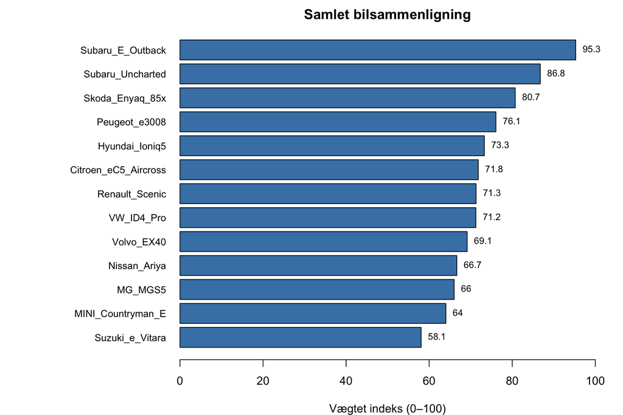

## Hvem vinder hver kategori

| Kategori | Vægt | Vinder |
| --- | --- | --- |
| Driftsikkerhed | 8 | Subaru_Uncharted, Subaru_E_Outback |
| Personsikkerhed | 7 | Peugeot_e3008, Hyundai_Ioniq5, Nissan_Ariya, Renault_Scenic, MINI_Countryman_E, VW_ID4_Pro, Subaru_E_Outback, Volvo_EX40, Skoda_Enyaq_85x |
| Dårligt føre/sne | 6 | Subaru_E_Outback |
| Samlet økonomi | 5 | Suzuki_e_Vitara |
| Rummelig | 4 | Subaru_E_Outback |
| Komfort (for- og bagsæder) | 3 | Hyundai_Ioniq5 |
| Fartbump+rundkørsel | 1 | Subaru_Uncharted, Subaru_E_Outback |